# US Residential Construction Spending - ARIMA Modeling and Forecasting

Author

Ankit Mishra

# Data Manipulation and Stationarity Analysis

```python
import pandas as pd
import numpy as np
import matplotlib.pyplot as plt
from statsmodels.tsa.stattools import kpss

df = pd.read_excel(r"C:\Users\akm10\Downloads\construction_spending.xlsx")
df["date"] = pd.to_datetime(df["date"])
df = df.set_index("date")

ts = df["construction_spending"].dropna()
```

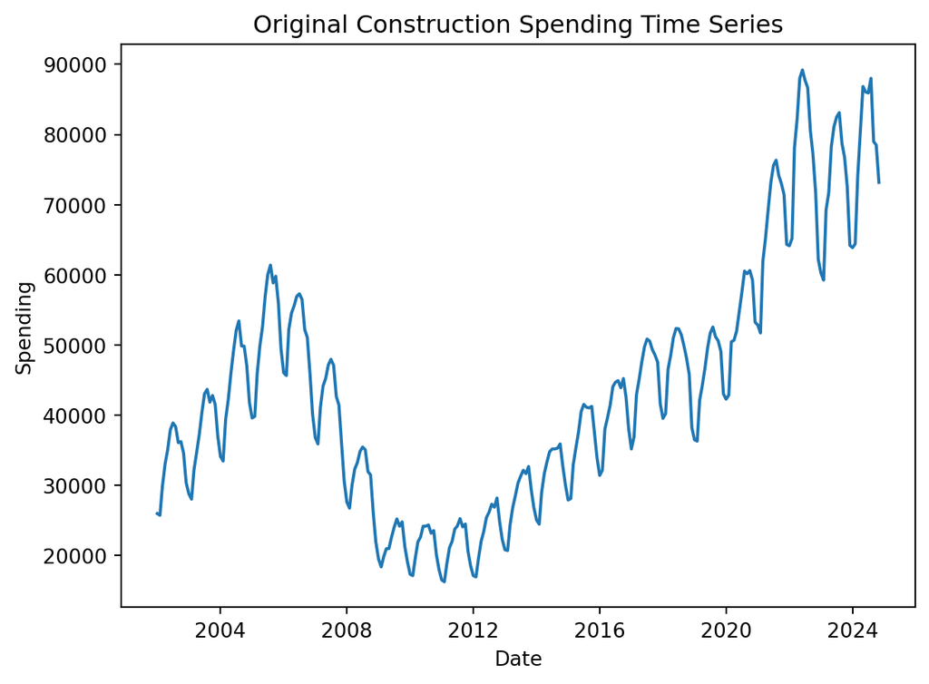

```
Figure 1: Original Construction Spending Time Series
```

```python
# ---------------------------------------------------
# Plot original series
# ---------------------------------------------------

plt.figure()
plt.plot(ts)
plt.title("Original Construction Spending Time Series")
plt.xlabel("Date")
plt.ylabel("Spending")
plt.show()

print("Figure 1: Original Construction Spending Time Series")
```

This plot shows a clear upward long-term trend in construction spending, along with strong recurring seasonal fluctuations. Because the mean changes over time, the series is not mean stationary.

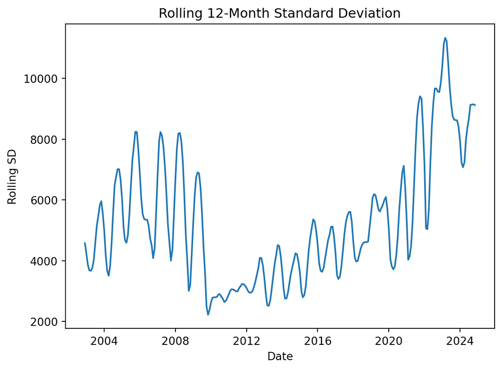

```
Figure 2: Rolling 12-Month Standard Deviation
```

```python
# ---------------------------------------------------
# Rolling standard deviation (variance stationarity)
# ---------------------------------------------------

rolling_sd = ts.rolling(12).std()

plt.figure()
plt.plot(rolling_sd)
plt.title("Rolling 12-Month Standard Deviation")
plt.xlabel("Date")
plt.ylabel("Rolling SD")
plt.show()

print("Figure 2: Rolling 12-Month Standard Deviation")
```

The rolling standard deviation shows significant variability over time, indicating that the variance is not constant. This suggests that the series is not variance stationary.

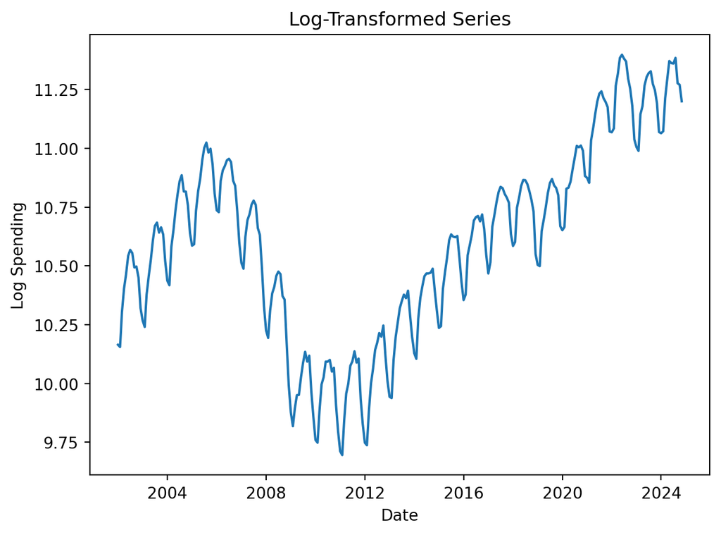

```
Figure 3: Log-Transformed Series
```

```python
# ---------------------------------------------------
# Log transformation (variance stabilization)
# ---------------------------------------------------

ts_log = np.log(ts)

plt.figure()
plt.plot(ts_log)
plt.title("Log-Transformed Series")
plt.xlabel("Date")
plt.ylabel("Log Spending")
plt.show()
print("Figure 3: Log-Transformed Series")
```

The log transformation has helped to stabilize the variance, as the fluctuations appear more consistent over time. However, the series still exhibits a strong upward trend and seasonality, so it is not yet mean stationary.